# A Demonstration of Workspace Building and Analysis in xRooFit

This tutorial is splits into two parts:

- Part I - Workspace (model and dataset) Building: Here you will learn about the structure of statistical models in HEP, including the terminology used to describe them.
- Part II - Statistical Analysis: You will use the workspace you have built in Part I to perform statistical analysis techniques such as running fits, generating datasets, and computing confidence limits.

Today we will perform a statistical analysis for a hypothetical search/measurement of a signal in some *signal region* (region A). Let us suppose we have designed some event selection for our signal region and come up with an *observable*, "some obs", that we will fill into a histogram. We produce this histogram from our **signal MC sample**, along with a histogram for some **minor irreducible backgrounds using background MC samples**. Both of these MC histograms have MC-statistical uncertainties on them. We also have produced that background histogram with a systematic variation applied, representing some experimental or theoretical uncertainty. Suppose further that we have concluded that our **main background should be *data driven***: we have designed a *control region* (region B) which is the same selection as our signal region except one of the selection cuts is inverted; the inverted cut gives a region rich in our dominant background. We plan to make a histogram of the observed events in this control region and apply a *transfer factor* to it before using it as the data-driven background prediction in the signal region. We plan to measure this transfer factor from the ratio between two further control regions (region C and region D), which are defined analagously to regions A and B respectively but with another selection cut inverted.

In summary, we suppose we have the following input to our statistical analysis:

- Observed data histogram in region D (`hDataD`)
- Observed data histogram in region C (`hDataC`)
- Observed data histogram in region B (`hDataB`)
- Signal prediction histogram in region A (`hSigA`)
- Irreducible background prediction histogram in region A (`hBkgA`)
- Systematic variation of irreducible background prediction histogram in region A (`hBkgA_syst`)

We will also create a copy of `hDataD` and `hDataB`, called `hDDBkgD` and `hDDBkgB`, and use those as the nominal DD predictions in the regions C,D and A,B respectively.

(We will suppose we haven't yet looked at the data in the signal region, i.e. we are currently "blinded").

Let's create all those histograms now and visualize them:

```python
import ROOT
print(ROOT.gROOT.GetVersion(),ROOT.xRooFit.GetVersion())
```

```
xRooFit -- Create/Explore/Modify Workspaces -- Development ongoing
                xRooFit : http://gitlab.cern.ch/will/xroofit
                Version: v0.0.1-19-g39a080f [2025-06-17 10:27:46 +0100]
6.34.08 v0.0.1-19-g39a080f
```

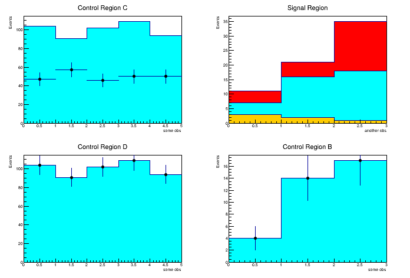

```python
ROOT.TH1.AddDirectory(False) # otherwise get warnings about possible memory leaks when cloning histograms
ROOT.gStyle.SetOptStat(0) # no stats box on plots
%jsroot off

# create pretend obs data
r = ROOT.TRandom3()
hDataD = ROOT.TH1D("obsData","Data;some obs;Events",5,0,5) # 5 bins
hDataD.SetMarkerStyle(20);hDataD.SetMarkerSize(0.5)
hDataC = hDataD.Clone()
hDataD.FillRandom("pol0",500)
hDataC.FillRandom("pol0",250) # suppose it had half the number of events in region C
hDataB = ROOT.TH1D("obsData","Data;another obs;Events",3,0,3) # 3 bins
hDataB.SetMarkerStyle(20);hDataB.SetMarkerSize(0.5)
hDataB.FillRandom("pol1",35)

# create pretend MC histograms of irreducible bkg and signal
hBkgA = hDataB.Clone("other") # use same histogram as region B. Name of histogram will be used for the sample name
hBkgA.SetTitle("Other bkg")
hBkgA.SetFillColor(ROOT.kOrange);hBkgA.SetMarkerStyle(0)
for i in range(hBkgA.GetNbinsX()):
    hBkgA.SetBinContent(i+1,3-i)
    hBkgA.SetBinError(i+1,hBkgA.GetBinContent(i+1)*(0.02*(i+1))) # pretend mc-stat uncertainty on bin content

hSigA = hDataB.Clone("sig")
hSigA.SetTitle("Signal")
hSigA.SetFillColor(ROOT.kRed);hSigA.SetMarkerStyle(0)
hSigA.SetBinContent(2,5);hSigA.SetBinError(2,0.5) # some pretend values

# create a systematic variation hist for irreducible bkg, representing a uniform 10% shift in this case
hBkgA_syst = hBkgA.Clone("alpha_sys1=1") # name of the histogram needs to be "parName=parVal"
for i in range(hBkgA_syst.GetNbinsX()):
    hBkgA_syst.SetBinContent(i+1,hBkgA.GetBinContent(i+1)*1.1)
    hBkgA_syst.SetBinError(i+1,0) # no uncerts on the variation (no errors on errors)

# create copies of hDataD and hDataB to use as the nominal DD predictions
# ensure no uncertainty on these, as will be determined by shape factors
hDDBkgD = hDataD.Clone("bkg")
hDDBkgD.SetTitle("DD Background")
hDDBkgD.SetMarkerStyle(0);hDDBkgD.SetFillColor(ROOT.kCyan)
hDDBkgB = hDataB.Clone("bkg")
hDDBkgB.SetTitle("DD Background")
hDDBkgB.SetMarkerStyle(0);hDDBkgB.SetFillColor(ROOT.kCyan)
for i in range(hDDBkgD.GetNbinsX()): hDDBkgD.SetBinError(i+1,0)
for i in range(hDDBkgB.GetNbinsX()): hDDBkgB.SetBinError(i+1,0)

# visualize the histograms
c = ROOT.TCanvas()
c.Divide(2,2)
c.cd(1)
hStack = ROOT.THStack("stack","Control Region C;some obs;Events");
hStack.Add(hDDBkgD)
hStack.DrawClone("hist")
hDataC.Draw("ESAME")
c.cd(2)
hStack = ROOT.THStack("stack","Signal Region;another obs;Events");
hStack.Add(hBkgA); hStack.Add(hDDBkgB); hStack.Add(hSigA)
hStack.DrawClone("hist")
c.cd(3)
hStack = ROOT.THStack("stack","Control Region D;some obs;Events");
hStack.Add(hDDBkgD)
hStack.DrawClone("hist")
hDataD.Draw("ESAME")
c.cd(4)
hStack = ROOT.THStack("stack","Control Region B;some obs;Events");
hStack.Add(hDDBkgB)
hStack.DrawClone("hist")
hDataB.Draw("ESAME")
c.cd(0)

ROOT.gPad.GetCanvas().Draw() # draw the current canvas
```

In this notebook, we will build a workspace from these histograms, then perform various statistical analyses with it...

## Workspace Building with xRooFit

Practical statistical analysis is done with *workspaces*, which are essentially a container object that can contain pdfs, datasets, and results of statistical analysis tasks such as fit results or hypothesis test scans. See [here](https://xroofit.readthedocs.io/en/latest/basics.html#workspaces) for more about workspaces.

We start by creating a workspace and wrapping it in an `xRooNode` to interact with it using the xRooFit API. Then we add a new empty multi-channel pdf (called `simPdf` conventionally).

```python
import ROOT as XRF # this will use the verion of xRooFit that is built in StatAnalysis
# import ROOT.Experimental.XRooFit as XRF # use this instead to take xRooFit from ROOT, if weren't using StatAnalysis
```

```python
ws = ROOT.RooWorkspace("combined","my workspace")
w = XRF.xRooNode(ws) # xRooNode is like a smart pointer, can take any ROOT object, augments with extra methods.
```

Now create a new top-level PDF called `simPdf` in the workspace (see here)

```python
w["pdfs"].Add("simPdf")
```

```
xRooNode<RooSimultaneous> simPdf
```

```
Info in <xRooNode::Add>: Created pdf RooSimultaneous::simPdf in workspace combined
```

We can verify that the creation of this top-level PDF has manifested a [regular observable](https://xroofit.readthedocs.io/en/latest/basics.html#summary-of-types-of-variable) that will appear in any datasets for this model, to indicate which channel each dataset entry is assigned to...

```python
w.robs().Print() # show list of regular observables of the workspace
```

```
combined/.robs: RooArgList::combined.robs
0) channelCat : RooCategory::channelCat = (idx = -2147483648)
```

Now create the four channels in your top-level multi-channel pdf ([see here](https://xroofit.readthedocs.io/en/latest/workspaceBuilding.html#channels):

```python
for name,title in [("CR_C","Control Region C"),("SR_A","Signal Region A"),("CR_D","Control Region D"),("CR_B","Control Region B")]:
    # Create a channel with given name and title
    w["pdfs/simPdf"].Add(name).SetTitle(title)
```

```
Info in <xRooNode::Vary>: Created channel RooProdPdf::simPdf_CR_C in model simPdf
Info in <xRooNode::Vary>: Created channel RooProdPdf::simPdf_SR_A in model simPdf
Info in <xRooNode::Vary>: Created channel RooProdPdf::simPdf_CR_D in model simPdf
Info in <xRooNode::Vary>: Created channel RooProdPdf::simPdf_CR_B in model simPdf
```

```
combined/simPdf: RooSimultaneous::simPdf
0) .indexCat : RooCategory::channelCat = CR_B(idx = 3)

1) channelCat=CR_C : RooProdPdf::simPdf_CR_C
2) channelCat=SR_A : RooProdPdf::simPdf_SR_A
3) channelCat=CR_D : RooProdPdf::simPdf_CR_D
4) channelCat=CR_B : RooProdPdf::simPdf_CR_B
combined/simPdf/.vars: RooArgList::combined/simPdf.vars
!robs
 0) channelCat : RooCategory::channelCat = CR_B(idx = 3)
```

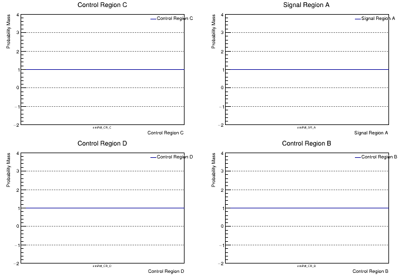

```python
w["pdfs/simPdf"].Draw()
ROOT.gPad.GetCanvas().Draw()
w["pdfs/simPdf"].Print() # list the channels.
w["pdfs/simPdf"].vars().Print() # list the variables
```

### Adding a sample, with MC-stat errors

Now let's add our first histogram into the model. We will add `hBkgA` to the `SR_A` region ([see second example here](https://xroofit.readthedocs.io/en/latest/workspaceBuilding.html#samples):

```python
w["pdfs/simPdf/SR_A"].Add(hBkgA)
```

```
xRooNode<RooProduct> other
```

```
Info in <xRooNode::Multiply>: Created RooRealSumPdf::simPdf_SR_A_samples in channel simPdf_SR_A
Info in <xRooNode::Multiply>: Created Shape factor simPdf_SR_A_samples_other_statFactor in prod_simPdf_SR_A_samples_other
Info in <xRooNode::Constrain>: Added poisson constraint pdf RooPoisson::pois_stat_simPdf_SR_A_samples_bin1 (tau=2500) for stat_simPdf_SR_A_samples_bin1
Info in <xRooNode::Constrain>: Added poisson constraint pdf RooPoisson::pois_stat_simPdf_SR_A_samples_bin2 (tau=625) for stat_simPdf_SR_A_samples_bin2
Info in <xRooNode::Constrain>: Added poisson constraint pdf RooPoisson::pois_stat_simPdf_SR_A_samples_bin3 (tau=277.778) for stat_simPdf_SR_A_samples_bin3
Info in <xRooNode::Add>: Created SimpleDensity factor RooHistFunc::simPdf_SR_A_samples_other for simPdf_SR_A_samples
```

Adding the histogram to the signal region caused a lot of things to happen:

1. A new `samples` node was created in the signal region, which is a `RooRealSumPdf` that represents the sum of many samples
2. A new factor of type `SimpleDensity` was created and added to the `samples` node.
   - This triggered the creation of a new regular observable (name given by the x-axis name from the histogram)
   - It also triggers creation of a prespecified parameter (called `1`) that is used as the sample's coefficient ([see here](https://xroofit.readthedocs.io/en/latest/workspaceBuilding.html#samples) for more info)
3. This new factor was scaled by a new factor of type `Shape` with parameters that will represent the mc-stat uncertainty
   - This triggered the creation of three floating parameters (prefixed by `stat_`), and three constant (prespecified) parameters (prefixed by `tau_`)
4. The mc-stat uncertainty factors were *constrained* by adding Poisson constraint terms to the channel PDF
   - This triggered the creation of three global observables (prefixed by `globs_`)

We can inspect all of this with the `Print` method, as well as visualize the result the usual way:

```
combined/simPdf: RooSimultaneous::simPdf
0) .indexCat : RooCategory::channelCat = SR_A(idx = 1)

1) channelCat=CR_C : RooProdPdf::simPdf_CR_C
2) channelCat=SR_A : RooProdPdf::simPdf_SR_A
 0) samples : RooRealSumPdf::simPdf_SR_A_samples
  0) other : RooProduct::prod_simPdf_SR_A_samples_other
   0) other : RooHistFunc::simPdf_SR_A_samples_other [SimpleDensity]
   1) statFactor : ParamHistFunc::simPdf_SR_A_samples_other_statFactor [Shape]
 1) pois_stat_simPdf_SR_A_samples_bin1 : RooPoisson::pois_stat_simPdf_SR_A_samples_bin1
  0) .x : RooRealVar::globs_stat_simPdf_SR_A_samples_bin1 = 2500 C  L(2250 - 2750)
  1) .mean : RooProduct::mean_stat_simPdf_SR_A_samples_bin1
   0) stat_simPdf_SR_A_samples_bin1 : RooRealVar::stat_simPdf_SR_A_samples_bin1 = 1 +/- 0.02  L(0.9 - 1.1)
   1) tau_stat_simPdf_SR_A_samples_bin1 : RooConstVar::tau_stat_simPdf_SR_A_samples_bin1 = 2500
 2) pois_stat_simPdf_SR_A_samples_bin2 : RooPoisson::pois_stat_simPdf_SR_A_samples_bin2
  0) .x : RooRealVar::globs_stat_simPdf_SR_A_samples_bin2 = 625 C  L(500 - 750)
  1) .mean : RooProduct::mean_stat_simPdf_SR_A_samples_bin2
   0) stat_simPdf_SR_A_samples_bin2 : RooRealVar::stat_simPdf_SR_A_samples_bin2 = 1 +/- 0.04  L(0.8 - 1.2)
   1) tau_stat_simPdf_SR_A_samples_bin2 : RooConstVar::tau_stat_simPdf_SR_A_samples_bin2 = 625
 3) pois_stat_simPdf_SR_A_samples_bin3 : RooPoisson::pois_stat_simPdf_SR_A_samples_bin3
  0) .x : RooRealVar::globs_stat_simPdf_SR_A_samples_bin3 = 277.778 C  L(194.444 - 361.111)
  1) .mean : RooProduct::mean_stat_simPdf_SR_A_samples_bin3
   0) stat_simPdf_SR_A_samples_bin3 : RooRealVar::stat_simPdf_SR_A_samples_bin3 = 1 +/- 0.06  L(0.7 - 1.3)
   1) tau_stat_simPdf_SR_A_samples_bin3 : RooConstVar::tau_stat_simPdf_SR_A_samples_bin3 = 277.778
3) channelCat=CR_D : RooProdPdf::simPdf_CR_D
4) channelCat=CR_B : RooProdPdf::simPdf_CR_B
combined/simPdf/.vars: RooArgList::combined/simPdf.vars
!robs
 0) channelCat : RooCategory::channelCat = SR_A(idx = 1)

 2) xaxis : RooRealVar::xaxis = 1.5  L(0 - 3) B(3)
!pp
 1) 1 : RooRealVar::1 = 1 C  L(-INF - +INF)
 6) tau_stat_simPdf_SR_A_samples_bin1 : RooConstVar::tau_stat_simPdf_SR_A_samples_bin1 = 2500
 7) tau_stat_simPdf_SR_A_samples_bin2 : RooConstVar::tau_stat_simPdf_SR_A_samples_bin2 = 625
 8) tau_stat_simPdf_SR_A_samples_bin3 : RooConstVar::tau_stat_simPdf_SR_A_samples_bin3 = 277.778
!np
 3) stat_simPdf_SR_A_samples_bin1 : RooRealVar::stat_simPdf_SR_A_samples_bin1 = 1 +/- 0.02  L(0.9 - 1.1)
 4) stat_simPdf_SR_A_samples_bin2 : RooRealVar::stat_simPdf_SR_A_samples_bin2 = 1 +/- 0.04  L(0.8 - 1.2)
 5) stat_simPdf_SR_A_samples_bin3 : RooRealVar::stat_simPdf_SR_A_samples_bin3 = 1 +/- 0.06  L(0.7 - 1.3)
!globs
 9) globs_stat_simPdf_SR_A_samples_bin1 : RooRealVar::globs_stat_simPdf_SR_A_samples_bin1 = 2500 C  L(2250 - 2750)
 10) globs_stat_simPdf_SR_A_samples_bin2 : RooRealVar::globs_stat_simPdf_SR_A_samples_bin2 = 625 C  L(500 - 750)
 11) globs_stat_simPdf_SR_A_samples_bin3 : RooRealVar::globs_stat_simPdf_SR_A_samples_bin3 = 277.778 C  L(194.444 - 361.111)
```

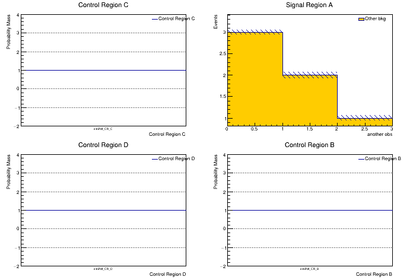

```python
w["pdfs/simPdf"].Print("depth=3")
w["pdfs/simPdf"].vars().Print() # list all the variables (obs and pars) of the pdf
w["pdfs/simPdf"].Draw("E") # using "E" will also draw an error band for the total uncertainty on the model prediction
ROOT.gPad.GetCanvas().Draw()
```

### Adding a systematic variation (Varying a sample)

```python
w["pdfs/simPdf/SR_A/other"].Vary(hBkgA_syst)
```

```
xRooNode<RooHistFunc> other
```

This has promoted our `SimpleDensity` factor into a `HistoDensity` factor. Additionally, a symmetrized version of the variation has been created and added as a variation

```python
w["pdfs/simPdf/SR_A/samples/other"].Print("depth=1")
w["pdfs/simPdf/SR_A/samples/other/other"].printAllInterpCodes()
```

```
combined/simPdf/channelCat=SR_A/samples/other: RooProduct::prod_simPdf_SR_A_samples_other[ simPdf_SR_A_samples_other * simPdf_SR_A_samples_other_statFactor ] = 2
0) statFactor : ParamHistFunc::simPdf_SR_A_samples_other_statFactor [Shape]
 0) stat_simPdf_SR_A_samples_bin1 : RooRealVar::stat_simPdf_SR_A_samples_bin1 = 1 +/- 0.02  L(0.9 - 1.1)
 1) stat_simPdf_SR_A_samples_bin2 : RooRealVar::stat_simPdf_SR_A_samples_bin2 = 1 +/- 0.04  L(0.8 - 1.2)
 2) stat_simPdf_SR_A_samples_bin3 : RooRealVar::stat_simPdf_SR_A_samples_bin3 = 1 +/- 0.06  L(0.7 - 1.3)
1) other : PiecewiseInterpolation::simPdf_SR_A_samples_other [HistoDensity]
 0) nominal : RooHistFunc::simPdf_SR_A_samples_other_nominal
 1) alpha_sys1=1 : RooHistFunc::simPdf_SR_A_samples_other_nominal_alpha_sys1_up
 2) alpha_sys1=-1 : RooHistFunc::simPdf_SR_A_samples_other_nominal_alpha_sys1_down
[#1] INFO:InputArguments -- interp code for alpha_sys1 = 4
```

So far all we have done is make our sample node dependent on the `alpha_sys1` parameter. We now also want to constrain that parameter, which conventionally is with a normal gaussian (a gaussian where the parameter is the mean, the observable is a global observable with value equal to 0, and the standard deviation of the gaussian is 1).

```python
w["pdfs/simPdf"].pars()["alpha_sys1"].Constrain("normal")
w["pdfs/simPdf"].pars()["alpha_sys1"].SetTitle("#alpha_{sys1}") # give it a nice title as well
```

```
Info in <xRooNode::Constrain>: Added gaussian constraint pdf RooGaussian::gaus_alpha_sys1 (mean=0,sigma=1) for alpha_sys1
```

The above line created a new *global observable* (`globs_alpha_sys1`) as well as adding a gaussian to the channel's PDF (which required the creation of a new prespecified parameter for the standard deviation of the gaussian)

```
combined/simPdf: RooSimultaneous::simPdf
0) .indexCat : RooCategory::channelCat = CR_B(idx = 3)

1) channelCat=CR_C : RooProdPdf::simPdf_CR_C
2) channelCat=SR_A : RooProdPdf::simPdf_SR_A
 0) samples : RooRealSumPdf::simPdf_SR_A_samples
  0) other : RooProduct::prod_simPdf_SR_A_samples_other
   0) statFactor : ParamHistFunc::simPdf_SR_A_samples_other_statFactor [Shape]
   1) other : PiecewiseInterpolation::simPdf_SR_A_samples_other [HistoDensity]
 1) pois_stat_simPdf_SR_A_samples_bin1 : RooPoisson::pois_stat_simPdf_SR_A_samples_bin1
  0) .x : RooRealVar::globs_stat_simPdf_SR_A_samples_bin1 = 2500 C  L(2250 - 2750)
  1) .mean : RooProduct::mean_stat_simPdf_SR_A_samples_bin1
   0) stat_simPdf_SR_A_samples_bin1 : RooRealVar::stat_simPdf_SR_A_samples_bin1 = 1 +/- 0.02  L(0.9 - 1.1)
   1) tau_stat_simPdf_SR_A_samples_bin1 : RooConstVar::tau_stat_simPdf_SR_A_samples_bin1 = 2500
 2) pois_stat_simPdf_SR_A_samples_bin2 : RooPoisson::pois_stat_simPdf_SR_A_samples_bin2
  0) .x : RooRealVar::globs_stat_simPdf_SR_A_samples_bin2 = 625 C  L(500 - 750)
  1) .mean : RooProduct::mean_stat_simPdf_SR_A_samples_bin2
   0) stat_simPdf_SR_A_samples_bin2 : RooRealVar::stat_simPdf_SR_A_samples_bin2 = 1 +/- 0.04  L(0.8 - 1.2)
   1) tau_stat_simPdf_SR_A_samples_bin2 : RooConstVar::tau_stat_simPdf_SR_A_samples_bin2 = 625
 3) pois_stat_simPdf_SR_A_samples_bin3 : RooPoisson::pois_stat_simPdf_SR_A_samples_bin3
  0) .x : RooRealVar::globs_stat_simPdf_SR_A_samples_bin3 = 277.778 C  L(194.444 - 361.111)
  1) .mean : RooProduct::mean_stat_simPdf_SR_A_samples_bin3
   0) stat_simPdf_SR_A_samples_bin3 : RooRealVar::stat_simPdf_SR_A_samples_bin3 = 1 +/- 0.06  L(0.7 - 1.3)
   1) tau_stat_simPdf_SR_A_samples_bin3 : RooConstVar::tau_stat_simPdf_SR_A_samples_bin3 = 277.778
 4) gaus_alpha_sys1 : RooGaussian::gaus_alpha_sys1
  0) .x : RooRealVar::globs_alpha_sys1 = 0 C  L(-10 - 10)
  1) .mean : RooRealVar::alpha_sys1 = 0 +/- 1  L(-5 - 5)
  2) .sigma : RooConstVar::sigma_alpha_sys1 = 1
3) channelCat=CR_D : RooProdPdf::simPdf_CR_D
4) channelCat=CR_B : RooProdPdf::simPdf_CR_B
combined/simPdf/.vars: RooArgList::combined/simPdf.vars
!robs
 0) channelCat : RooCategory::channelCat = CR_B(idx = 3)

 2) xaxis : RooRealVar::xaxis = 1.5  L(0 - 3) B(3)
!pp
 1) 1 : RooRealVar::1 = 1 C  L(-INF - +INF)
 7) tau_stat_simPdf_SR_A_samples_bin1 : RooConstVar::tau_stat_simPdf_SR_A_samples_bin1 = 2500
 8) tau_stat_simPdf_SR_A_samples_bin2 : RooConstVar::tau_stat_simPdf_SR_A_samples_bin2 = 625
 9) tau_stat_simPdf_SR_A_samples_bin3 : RooConstVar::tau_stat_simPdf_SR_A_samples_bin3 = 277.778
 10) sigma_alpha_sys1 : RooConstVar::sigma_alpha_sys1 = 1
!np
 3) alpha_sys1 : RooRealVar::alpha_sys1 = 0 +/- 1  L(-5 - 5)
 4) stat_simPdf_SR_A_samples_bin1 : RooRealVar::stat_simPdf_SR_A_samples_bin1 = 1 +/- 0.02  L(0.9 - 1.1)
 5) stat_simPdf_SR_A_samples_bin2 : RooRealVar::stat_simPdf_SR_A_samples_bin2 = 1 +/- 0.04  L(0.8 - 1.2)
 6) stat_simPdf_SR_A_samples_bin3 : RooRealVar::stat_simPdf_SR_A_samples_bin3 = 1 +/- 0.06  L(0.7 - 1.3)
!globs
 11) globs_stat_simPdf_SR_A_samples_bin1 : RooRealVar::globs_stat_simPdf_SR_A_samples_bin1 = 2500 C  L(2250 - 2750)
 12) globs_stat_simPdf_SR_A_samples_bin2 : RooRealVar::globs_stat_simPdf_SR_A_samples_bin2 = 625 C  L(500 - 750)
 13) globs_stat_simPdf_SR_A_samples_bin3 : RooRealVar::globs_stat_simPdf_SR_A_samples_bin3 = 277.778 C  L(194.444 - 361.111)
 14) globs_alpha_sys1 : RooRealVar::globs_alpha_sys1 = 0 C  L(-10 - 10)
```

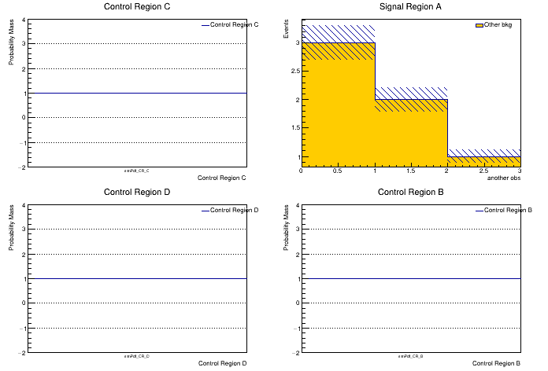

```python
w["pdfs/simPdf"].Print("depth=3")
w["pdfs/simPdf"].vars().Print() # list all the variables (obs and pars) of the pdf
w["pdfs/simPdf"].Draw("E")
ROOT.gPad.GetCanvas().Draw()
```

### Creating samples for the data-driven ABCD background

In regions B and D we will have samples with unconstrained shape factors to be able to fit to the data in these regions. The regions A and C will have the same shape factors in them but will be multplied for a transfer factor.

```
Info in <xRooNode::Multiply>: Created RooRealSumPdf::simPdf_CR_D_samples in channel simPdf_CR_D
Info in <xRooNode::Add>: Created SimpleDensity factor RooHistFunc::simPdf_CR_D_samples_bkg for simPdf_CR_D_samples
Info in <xRooNode::Multiply>: Created RooRealSumPdf::simPdf_CR_C_samples in channel simPdf_CR_C
Info in <xRooNode::Add>: Created SimpleDensity factor RooHistFunc::simPdf_CR_C_samples_bkg for simPdf_CR_C_samples
Info in <xRooNode::Multiply>: Created RooRealSumPdf::simPdf_CR_B_samples in channel simPdf_CR_B
Info in <xRooNode::Add>: Created SimpleDensity factor RooHistFunc::simPdf_CR_B_samples_bkg for simPdf_CR_B_samples
Info in <xRooNode::Add>: Created SimpleDensity factor RooHistFunc::simPdf_SR_A_samples_bkg for simPdf_SR_A_samples
```

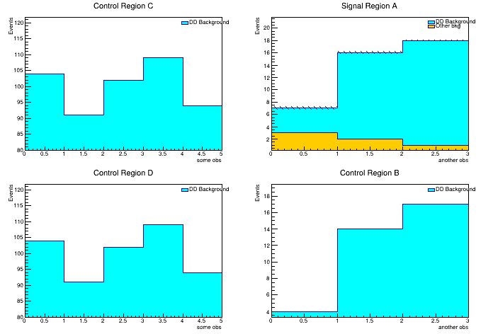

```python
w["pdfs/simPdf/CR_D"].Add(hDDBkgD)
w["pdfs/simPdf/CR_C"].Add(hDDBkgD)
w["pdfs/simPdf/CR_B"].Add(hDDBkgB)
w["pdfs/simPdf/SR_A"].Add(hDDBkgB)
w["pdfs/simPdf"].Draw("E")
ROOT.gPad.GetCanvas().Draw()
```

Now we create shape factors for the samples we just added to regions B and D, and use the *same* factor on the samples in region A and C respectively. See [here](https://xroofit--15.org.readthedocs.build/en/15/workspaceBuilding.html#factors) for a reminder on creating shape Factors.

```python
w["pdfs/simPdf/CR_D/bkg"].Multiply("shapeFactorCD","shape")
w["pdfs/simPdf/CR_C/bkg"].Multiply(w["pdfs/simPdf/CR_D/bkg/shapeFactorCD"]) # the exact same factor is used in region C and D
w["pdfs/simPdf/CR_B/bkg"].Multiply("shapeFactorAB","shape")
w["pdfs/simPdf/SR_A/bkg"].Multiply(w["pdfs/simPdf/CR_B/bkg/shapeFactorAB"])
```

```
xRooNode<ParamHistFunc> shapeFactorAB
```

```
Info in <xRooNode::Multiply>: Created Shape factor shapeFactorCD in prod_simPdf_CR_D_samples_bkg
Info in <xRooNode::Multiply>: Scaled simPdf_CR_D_samples_bkg by new shape factor shapeFactorCD
Info in <xRooNode::Multiply>: Created Shape factor shapeFactorAB in prod_simPdf_CR_B_samples_bkg
Info in <xRooNode::Multiply>: Scaled simPdf_CR_B_samples_bkg by new shape factor shapeFactorAB
```

```python
# putting the transferFactor in the coefs() because conventionally this is where observable-independent factors go
w["pdfs/simPdf/CR_C/bkg"].coefs().Multiply("transferFactor","norm").SetTitle("TF")
w["pdfs/simPdf/SR_A/bkg"].coefs().Multiply(w["pdfs/simPdf/CR_C/bkg"].coefs()["transferFactor"])
```

```
xRooNode<RooRealVar> transferFactor
```

```
Info in <xRooNode::Multiply>: Scaled 1 by new norm factor transferFactor
Warning in <xRooNode::acquire>: Renaming to coefs_bkg_1
```

### Adding the signal sample with independent MC-stat errors and a signal strength norm factor

We will now add the signal sample to the signal region. We want to ensure it has its own MC-stat uncertainties (any sample that has its own norm factor should also have its own MC-stat error shape sys). See the [note here](https://xroofit.readthedocs.io/en/latest/workspaceBuilding.html#samples) about specifying an added histogram get its own MC stat uncertainty treatment.

```python
hSigA.SetOption("statPrefix=stat_sig_SR_A") # this line ensures the factor will generate shape factor parameters independent of the existing ones
w["pdfs/simPdf/SR_A"].Add(hSigA)
w["pdfs/simPdf/SR_A/sig"].coefs().Multiply("mu","norm").SetTitle("#mu")
w.poi().Add("mu") # promotes mu to the status of being a POI
```

```
xRooNode<RooRealVar> mu
```

```
Info in <xRooNode::Multiply>: Created Shape factor simPdf_SR_A_samples_sig_statFactor in prod_simPdf_SR_A_samples_sig
Info in <xRooNode::Constrain>: Added poisson constraint pdf RooPoisson::pois_stat_sig_SR_A_bin1 (tau=4) for stat_sig_SR_A_bin1
Info in <xRooNode::Constrain>: Added poisson constraint pdf RooPoisson::pois_stat_sig_SR_A_bin2 (tau=100) for stat_sig_SR_A_bin2
Info in <xRooNode::Constrain>: Added poisson constraint pdf RooPoisson::pois_stat_sig_SR_A_bin3 (tau=17) for stat_sig_SR_A_bin3
Info in <xRooNode::Add>: Created SimpleDensity factor RooHistFunc::simPdf_SR_A_samples_sig for simPdf_SR_A_samples
Info in <xRooNode::Multiply>: Scaled 1 by new norm factor mu
```

### Adding the observed data

To finish our workspace off, we just add the data to each region

```python
w["pdfs/simPdf/CR_D"].datasets().Add(hDataD)
w["pdfs/simPdf/CR_C"].datasets().Add(hDataC)
w["pdfs/simPdf/CR_B"].datasets().Add(hDataB)
```

```
xRooNode<RooDataSet> obsData
```

```
[#1] INFO:ObjectHandling -- RooWorkspace::import(combined) importing dataset obsData
```

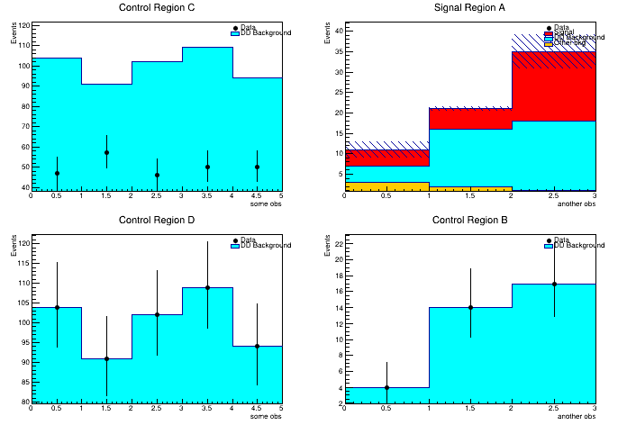

```python
w["pdfs/simPdf"].Draw("E")
ROOT.gPad.GetCanvas().Draw()
```

```python
w.SaveAs("abcdWorkspace.root") # save the state of the workspace so far
```

```
Info in <xRooNode::SaveAs>: combined saved to abcdWorkspace.root
```

### Recap of Part I learning outcomes

Here is a checklist of things you should have learned about from the first part of this tutorial:

- Types of variable: Discrete vs Continuous.
- Observables vs Parameters:
  - Regular observables
  - Global observables
  - Prespecified parameters
  - floating parameters: Nuisance parameters and Parameters of Interest
- Channels, samples, and sample coefficients
- Samples are built ouf of Factors:
  - SimpleDensity
  - HistoDensity
  - Shape
  - Norm
  - Overall
- Constraining parameters (Factors -> Sys)
- Treatment of MC-stat uncertainties (ShapeSys shared by multiple samples)
- Workspaces as containers of PDFs and datasets
- Building workspaces from input histograms
- Exploring the content of a workspace, and the structure of a PDF

### Running and validating a fit

So far we haven't got any data in the signal region (we are "blinded"), so the only fit we can do at this stage is a fit to the control regions. So we will run a fit to just these regions. Before running any fits, it can be a good idea to save the initial state of the parameters, just in case we want to restore these at a future point. The `fitResult` of the workspace represents the state of the workspace:

```python
fr = w.fitResult() # represents initial state
fr.get().SetNameTitle("initial","Initial state")
w.Add(fr)
```

```
xRooNode<RooFitResult> ad6e891a-4b5d-11f0-bdba-49b8640abeef
```

Lets run a fit to the control regions, after setting the POI equal to 0 and holding it constant. This is an example of a *conditional fit*:

```python
w.poi()[0].setVal(0); w.poi()[0].setConstant() # set the poi equal to 0 and hold it constant
fr = w["pdfs/simPdf"].reduced("CR*").nll("obsData").minimize() # run a fit
fr.get().SetNameTitle("CRs_mu0_cfit","CR #mu=0 cfit") # rename and title it
w.Add(fr) # add it to the workspace
w.SetFitResult(fr) # also make it the current state of the workspace
print("status =",fr.status(),"covQual =",fr.covQual(),"edm =",fr.edm())
# status should be 0, covQual should be 3, edm should be small (less than 1e-5 by default)
```

```
status = 0 covQual = 3 edm = 2.0881555827317615e-08
```

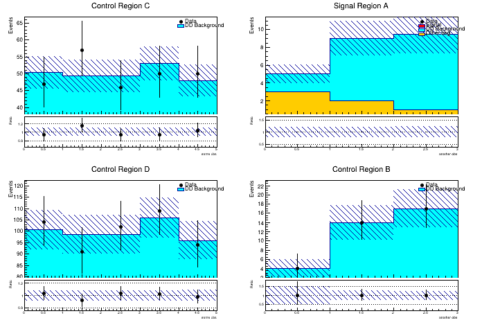

```python
w["pdfs/simPdf"].Draw("eratio")
ROOT.gPad.GetCanvas().Draw()
```

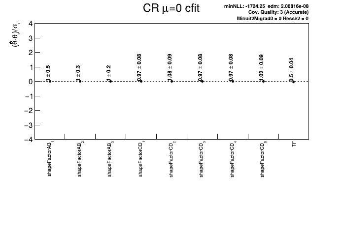

```python
# check the fit result is good ....
fr.Draw("pull")
ROOT.gPad.GetCanvas().Draw()
```

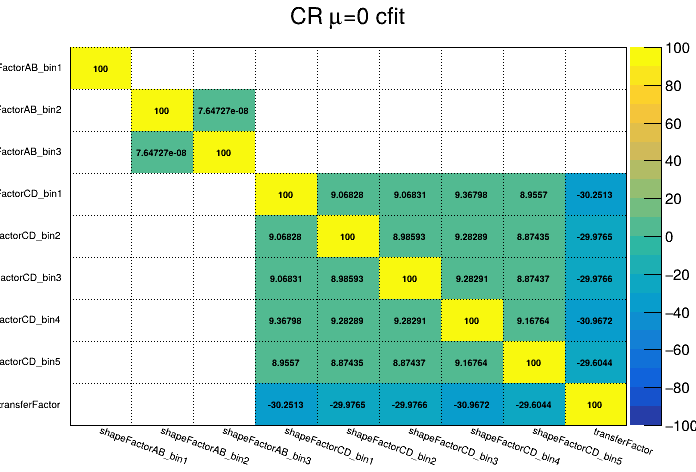

```python
# also check the correlation matrix
fr.Draw("corr10colztext") # draw the 10 strongest correlations
ROOT.gPad.GetCanvas().Draw()
```

```python
# can also compute goodness-of-fit p-value, which gives an estimate of how well the data is described by the post-fit model:
w["pdfs/simPdf"].reduced("CR*").nll("obsData").mainTermPgof()
```

```
0.5911275545316006
```

To perform a profile likelihood scan of some parameter, we can scan it like this:

```
[#1] INFO:Eval -- RooRealVar::setRange(transferFactor) new range named 'scan' created with bounds [0.4,0.6]
Info in <xRooHypoSpace::scan>: Using transferFactor scan range: 0.4 - 0.6
Info in <xRooHypoSpace::AddPoint>: Added new point @ transferFactor=0.4
Info in <xRooHypoSpace::AddPoint>: Added new point @ transferFactor=0.410526
Info in <xRooHypoSpace::AddPoint>: Added new point @ transferFactor=0.421053
Info in <xRooHypoSpace::AddPoint>: Added new point @ transferFactor=0.431579
Info in <xRooHypoSpace::AddPoint>: Added new point @ transferFactor=0.442105
Info in <xRooHypoSpace::AddPoint>: Added new point @ transferFactor=0.452632
Info in <xRooHypoSpace::AddPoint>: Added new point @ transferFactor=0.463158
Info in <xRooHypoSpace::AddPoint>: Added new point @ transferFactor=0.473684
Info in <xRooHypoSpace::AddPoint>: Added new point @ transferFactor=0.484211
Info in <xRooHypoSpace::AddPoint>: Added new point @ transferFactor=0.494737
Info in <xRooHypoSpace::AddPoint>: Added new point @ transferFactor=0.505263
Info in <xRooHypoSpace::AddPoint>: Added new point @ transferFactor=0.515789
Info in <xRooHypoSpace::AddPoint>: Added new point @ transferFactor=0.526316
Info in <xRooHypoSpace::AddPoint>: Added new point @ transferFactor=0.536842
Info in <xRooHypoSpace::AddPoint>: Added new point @ transferFactor=0.547368
Info in <xRooHypoSpace::AddPoint>: Added new point @ transferFactor=0.557895
Info in <xRooHypoSpace::AddPoint>: Added new point @ transferFactor=0.568421
Info in <xRooHypoSpace::AddPoint>: Added new point @ transferFactor=0.578947
Info in <xRooHypoSpace::AddPoint>: Added new point @ transferFactor=0.589474
Info in <xRooHypoSpace::AddPoint>: Added new point @ transferFactor=0.6
```

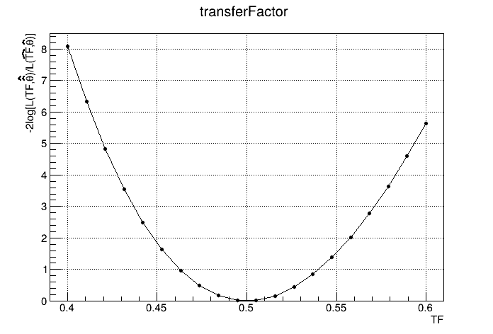

```python
hs = w["pdfs/simPdf"].reduced("CR*").nll("obsData").hypoSpace("transferFactor")
hs.scan("plr",20,0.4,0.6)
hs.Draw()
ROOT.gPad.GetCanvas().Draw()
```

Where the profile likelihood curve becomes equal to 1 can be used as an estimate of the 68% confidence interval on the parameter, i.e. the two values can be used as the $\pm 1\sigma$ uncertainties. These are known as the *asymmetric* errors or *minos* errors. The errors that are present in the fit result are from the diagonal elements of the covariance matrix. In the limit of large statistics the covariance matrix error (aka the *symmetric* error) will become equivalent to the *asymmetric* error.

We can get a sense of how different the errors are by testing what the value of the profile likelihood ratio is at the $\pm 1\sigma$ values given by the symmetric error:

```python
graph = hs.graph("ts") # gets a TGraphErrors of the test-statistic (the profile likelihood ratio) of the scan
par_hat = fr.floatParsFinal().find("transferFactor")
print("Value of PLR @ best-fit + error = ",graph.Eval(par_hat.getVal()+par_hat.getError()))
print("Value of PLR @ best-fit - error = ",graph.Eval(par_hat.getVal()-par_hat.getError()))
```

```
Value of PLR @ best-fit + error =  0.9440681186876239
Value of PLR @ best-fit - error =  1.0874876643213742
```

We can evaluate minos errors on any parameter by setting its `minos` attribute before running a fit:

```python
w.pars()["transferFactor"].setAttribute("minos")
fr2 = w["pdfs/simPdf"].reduced("CR*").nll("obsData").minimize() # rerun the fit
par_hat = fr2.floatParsFinal().find("transferFactor")
print("Value of PLR @ best-fit + error = ",graph.Eval(par_hat.getVal()+par_hat.getErrorHi()))
print("Value of PLR @ best-fit - error = ",graph.Eval(par_hat.getVal()+par_hat.getErrorLo()))
```

```
Value of PLR @ best-fit + error =  1.0127447211352414
Value of PLR @ best-fit - error =  1.004782812431617
```

From the above we see that the minos errors are indeed closer to where the PLL equals 1 (any difference will likely be due to at what precision the search algorithm runs for).

```python
w.pars()["transferFactor"].setAttribute("minos",False) # turn it back off for future fits
```

### Generating Hybrid datasets: using expected data in the signal region

Now lets use our CR mu=0 fit to create a dataset that uses the expected (asimov) data in the signal region, but the obs data in the CRs....

```python
# now generate the expected data in the SR:
hybridData = w["pdfs/simPdf"].reduced("SR_A").generate(fr,expected=True)
# add to the hybridData the obsData from the CRs:
hybridData.Add(w["pdfs/simPdf"].reduced("CR*").datasets()["obsData"])
# rename and retitle the data and add it to our workspace:
hybridData.get().SetNameTitle("hybridData","CR Data + SR Exp. (#mu=0)")
w.Add(hybridData)
```

```
xRooNode<nullptr> CRs_mu0_cfit_asimov
```

```
[#1] INFO:ObjectHandling -- RooWorkspace::import(combined) importing dataset hybridData
```

Let's create another hybrid dataset, this time with data in the signal region consistent with mu=1. Generally we would have to rerun a conditional fit to the CRs with mu=1 but mu isn't a parameter that features anywhere in the CRs of this model so we can just use the fit result we had before:

```python
w.poi()[0].setVal(1)
hybridData = w["pdfs/simPdf"].reduced("SR_A").generate(fr,True)
hybridData.Add(w["pdfs/simPdf"].reduced("CR*").datasets()["obsData"])
hybridData.get().SetNameTitle("hybridData2","CR Data + SR Exp. (#mu=1)")
w.Add(hybridData)
```

```
xRooNode<nullptr> CRs_mu0_cfit_asimov
```

```
[#1] INFO:ObjectHandling -- RooWorkspace::import(combined) importing dataset hybridData2
```

To show the model with, say, the second dataset, we must "check" (select) the dataset, and "uncheck" (deselect) the other datasets in the workspace, then draw the model:

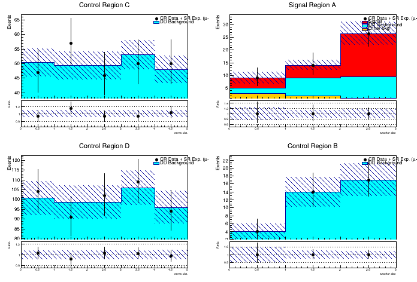

```python
w.datasets()["obsData"].SetChecked(False)
w.datasets()["hybridData"].SetChecked(False)
w.datasets()["hybridData2"].SetChecked(True)
w["pdfs/simPdf"].Draw("eratio")
ROOT.gPad.GetCanvas().Draw()
```

Now lets run an example full (all region) fit with this dataset:

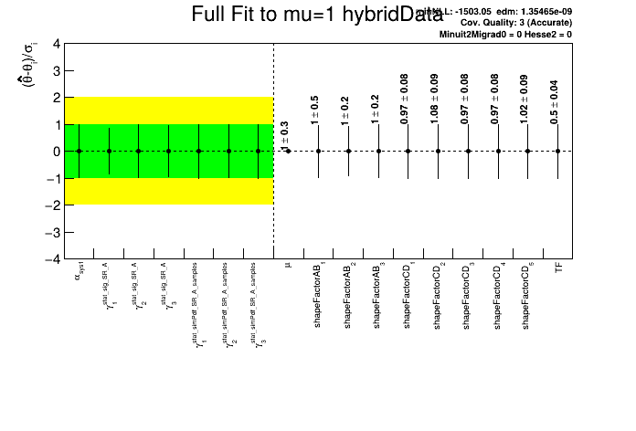

```python
w.poi()[0].setConstant(False)
fr = w["pdfs/simPdf"].nll("hybridData2").minimize()
fr.SetTitle("Full Fit to mu=1 hybridData")
fr.Draw("pull")
ROOT.gPad.GetCanvas().Draw()
```

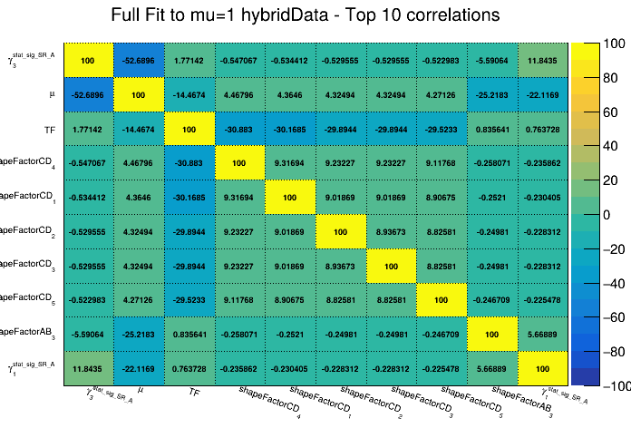

```python
# also check the correlation matrix - can you make sense of the largest correlations?
fr.Draw("corr10colztext")
ROOT.gPad.GetCanvas().Draw()
```

It's a popular task to produce an "impact plot". However impact is pretty much just telling you what the POI row of the correlation matrix looks like. Look at how the impact plot below lines up with the correlation matrix values for mu:

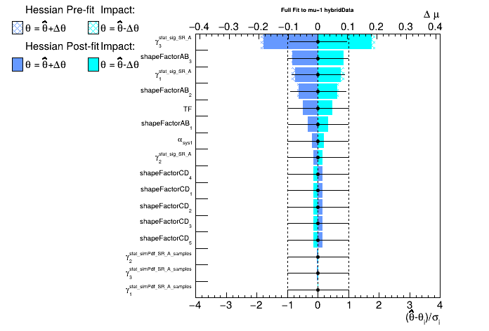

```python
fr.Draw("impact")
ROOT.gPad.GetCanvas().Draw()
```

### Running a CLs limit scan

Let's now run a CLs limit scan on the model with the hybrid dataset that has mu=1 expectated data in the signal region....

```
Info in <xRooHypoSpace::scan>: No physical range set for mu, setting to [0,inf]
[#1] INFO:Eval -- RooRealVar::setRange(mu) new range named 'physical' created with bounds [0,inf]
Info in <xRooHypoSpace::scan>: No altVal set for mu, setting to 0
Info in <xRooHypoSpace::AddPoint>: Added new point @ mu=0
Info in <xRooHypoSpace::AddPoint>: Added new point @ mu=2
Info in <xRooHypoSpace::findlimit>: pcls exp0 -- Testing new point @ mu=0.600587 (delta=1.55318)
Info in <xRooHypoSpace::AddPoint>: Added new point @ mu=0.600587
Info in <xRooHypoSpace::findlimit>: pcls exp0 -- Testing new point @ mu=0.513922 (delta=-0.570391)
Info in <xRooHypoSpace::AddPoint>: Added new point @ mu=0.513922
Info in <xRooHypoSpace::findlimit>: pcls exp0 -- Testing new point @ mu=0.570471 (delta=-0.0627626)
Info in <xRooHypoSpace::AddPoint>: Added new point @ mu=0.570471
Info in <xRooHypoSpace::findlimit>: pcls exp+1 -- Testing new point @ mu=0.949826 (delta=1.16557)
Info in <xRooHypoSpace::AddPoint>: Added new point @ mu=0.949826
Info in <xRooHypoSpace::findlimit>: pcls exp+1 -- Testing new point @ mu=0.838128 (delta=-0.263641)
Info in <xRooHypoSpace::AddPoint>: Added new point @ mu=0.838128
Info in <xRooHypoSpace::findlimit>: pcls exp+2 -- Testing new point @ mu=1.3414 (delta=0.730965)
Info in <xRooHypoSpace::AddPoint>: Added new point @ mu=1.3414
Info in <xRooHypoSpace::findlimit>: pcls exp+2 -- Testing new point @ mu=1.26588 (delta=-0.350787)
Info in <xRooHypoSpace::AddPoint>: Added new point @ mu=1.26588
Info in <xRooHypoSpace::findlimit>: pcls exp-1 -- Testing new point @ mu=0.342271 (delta=-0.379879)
Info in <xRooHypoSpace::AddPoint>: Added new point @ mu=0.342271
Info in <xRooHypoSpace::findlimit>: pcls exp-1 -- Testing new point @ mu=0.406931 (delta=0.118747)
Info in <xRooHypoSpace::AddPoint>: Added new point @ mu=0.406931
Info in <xRooHypoSpace::findlimit>: pcls exp-1 -- Testing new point @ mu=0.390995 (delta=-0.0540778)
Info in <xRooHypoSpace::AddPoint>: Added new point @ mu=0.390995
Info in <xRooHypoSpace::findlimit>: pcls exp-2 -- Testing new point @ mu=0.255046 (delta=-0.283069)
Info in <xRooHypoSpace::AddPoint>: Added new point @ mu=0.255046
Info in <xRooHypoSpace::findlimit>: pcls exp-2 -- Testing new point @ mu=0.292917 (delta=0.0547771)
Info in <xRooHypoSpace::AddPoint>: Added new point @ mu=0.292917
Info in <xRooHypoSpace::findlimit>: pcls exp-2 -- Testing new point @ mu=0.284559 (delta=-0.0327553)
Info in <xRooHypoSpace::AddPoint>: Added new point @ mu=0.284559
Info in <xRooHypoSpace::AddPoint>: Added new point @ mu=0.577004
Info in <xRooHypoSpace::findlimit>: pcls obs -- Testing new point @ mu=2.83213 (delta=inf)
Info in <xRooHypoSpace::AddPoint>: Added new point @ mu=2.83213
Info in <xRooHypoSpace::findlimit>: pcls obs -- Testing new point @ mu=1.52067 (delta=1.45556)
Info in <xRooHypoSpace::AddPoint>: Added new point @ mu=1.52067
Info in <xRooHypoSpace::findlimit>: pcls obs -- Testing new point @ mu=1.77732 (delta=1.17071)
Info in <xRooHypoSpace::AddPoint>: Added new point @ mu=1.77732
```

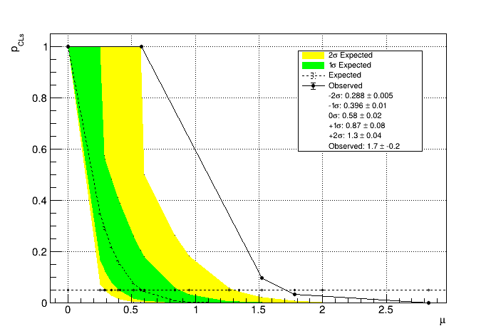

```python
hs = w["pdfs/simPdf"].nll("hybridData2").hypoSpace()
hs.scan("cls")
hs.Draw()
ROOT.gPad.GetCanvas().Draw()
```

The individual hypoPoints in the hypoSpace can be accessed and explored as follows. See https://root.cern.ch/doc/master/classROOT_1_1Experimental_1_1XRooFit_1_1xRooNLLVar_1_1xRooHypoPoint.html for all the methods available in a hypoPoint:

```python
for hp in hs:
    # hp.Print() # for example, show the status of the fits
    print("mu_test =",hp.fNullVal(),": pCLs =",hp.pCLs_asymp())
    cfit_null = hp.cfit_null(True)
    if cfit_null:
        print(" cfit_null status=",cfit_null.status()," covqual=",cfit_null.covQual()," mu_hat=",hp.mu_hat().getVal())
```

```
mu_test = 0.0 : pCLs = 1.000000 +/- 0.000000
mu_test = 2.0 : pCLs = 0.012471 +/- 0.000000
 cfit_null status= 0  covqual= 3  mu_hat= 0.9998371879175714
mu_test = 0.600587 : pCLs = 1.000000 +/- 0.000000
mu_test = 0.513922 : pCLs = 1.000000 +/- 0.000000
mu_test = 0.570471 : pCLs = 1.000000 +/- 0.000000
mu_test = 0.949826 : pCLs = 1.000000 +/- 0.000000
mu_test = 0.838128 : pCLs = 1.000000 +/- 0.000000
mu_test = 1.3414 : pCLs = 0.185512 +/- 0.000002
 cfit_null status= 0  covqual= 3  mu_hat= 0.9998371879175714
mu_test = 1.26588 : pCLs = 0.238566 +/- 0.000002
 cfit_null status= 0  covqual= 3  mu_hat= 0.9998371879175714
mu_test = 0.342271 : pCLs = 1.000000 +/- 0.000000
mu_test = 0.406931 : pCLs = 1.000000 +/- 0.000000
mu_test = 0.390995 : pCLs = 1.000000 +/- 0.000000
mu_test = 0.255046 : pCLs = 1.000000 +/- 0.000000
mu_test = 0.292917 : pCLs = 1.000000 +/- 0.000000
mu_test = 0.284559 : pCLs = 1.000000 +/- 0.000000
mu_test = 0.577004 : pCLs = 1.000000 +/- 0.000000
mu_test = 2.83213 : pCLs = 0.000214 +/- 0.000000
 cfit_null status= 0  covqual= 3  mu_hat= 0.9998371879175714
mu_test = 1.52067 : pCLs = 0.096322 +/- 0.000000
 cfit_null status= 0  covqual= 3  mu_hat= 0.9998371879175714
mu_test = 1.77732 : pCLs = 0.033639 +/- 0.000000
 cfit_null status= 0  covqual= 3  mu_hat= 0.9998371879175714
```